# Practical: Checking fitted model assumptions

Physalia workshop on GLMs

Bert van der Veen

# Background

All methods make assumptions, especially linear regression. Those assumptions help us in small samples, because they can ensure behavior of the estimators, and generally the statistics that underlays our analysis.

For linear regression, these assumptions focus on the error term, and they include:

1. a linear relationship of $\textbf{y}$ and $\textbf{x}$ (“linearity”)
2. normally distributed errors $\boldsymbol{\epsilon}$ (“normality”)
3. uncorrelated errors (“independence of errors”)
4. equal variance for all errors $\boldsymbol{\epsilon}$ (“homoscedasticity”)

When any of these assumptions is violated that may have consequences for the analysis. It does not mean that we cannot trust the analysis, but that either a) we cannot rely on a certain test or result or 2) we need large samples to be able to say anything about performance of the estimators or tests.

In this practical, we will focus on checking the assumptions graphically. There are tests for checking assumptions, but we do not explore those here. Once we have determined if an assumption is violated we can consider what the consequences are for our analysis.

Let’s continue with the example from practical 3:

```r
x <- runif(20, 3, 5)
z <- rnorm(20)
(y <- rnorm(20, mean = 1 + x*2))
```

```
##  [1]  8.972703 11.731668  8.261447  8.029925 10.809249  7.860326  7.752260
##  [8] 10.052541  9.377889 10.119522 11.302047  8.013552  6.687369 10.005762
## [15] 10.017388  9.968089  7.363633 10.475821  9.404487  7.344306
```

```r
reg <- lm(y~x+z)
```

the exact details may differ because the data is re-simulated here.

Each of the above assumptions can be checked with particular plots of the residuals $\hat{\boldsymbol{\epsilon}}$ and fitted values $\hat{\boldsymbol{\mu}}$ (these are the prediction of the model for the observed data). The residuals can be extracted from the model using the `residuals` function, and the fitted values using `fitted`:

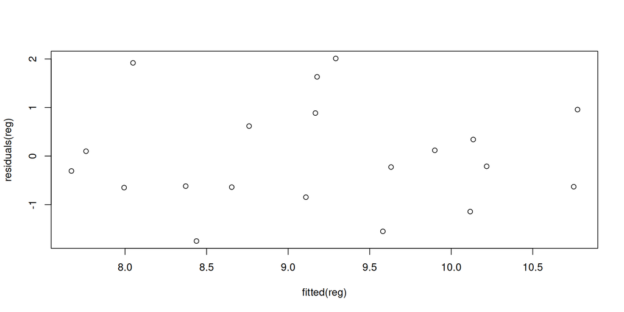

```r
plot(residuals(reg)~fitted(reg))
```

the residuals versus fitted plot is one of the most useful residual plots for linear regression. Roughly, if we see any kind of pattern, we should think a bit more deeply about our model. If we see no patterns we can proceed, and the linearity, homoscedasticity, and independence of errors assumptions are most likely met.

If the linearity assumption is not met, we may see curvature in the plot. If the unequal variance assumption is not met, we would see different amounts of vertical scatter in different parts of the plot. If we independence of errors assumption is not met, we might see residuals cluster in particular parts of the plot. In practice, this would then be further explored by plotting the residuals versus whatever variable we expect to invalidate the assumption (such as time, space, phylogeny, or otherwise).

The normality assumption is checked using a QQ-plot:

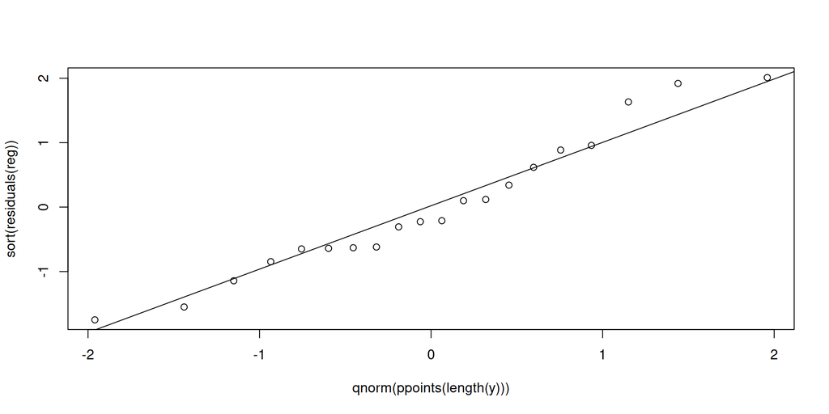

```r
plot(sort(residuals(reg)) ~qnorm(ppoints(length(y))))
qqline(residuals(reg))
```

which is slightly more involved in its construction. It requires using the following functions:

- `sort`: sorts a vector
- `residuals`
- `qnorm`: the quantile function for the normal distribution
- `ppoints`: calculates theoretical quantiles
- `qqline`: draws the diagonal line

In fact, we can draw all plots that we may need from the linear regression directly by using the `plot` function:

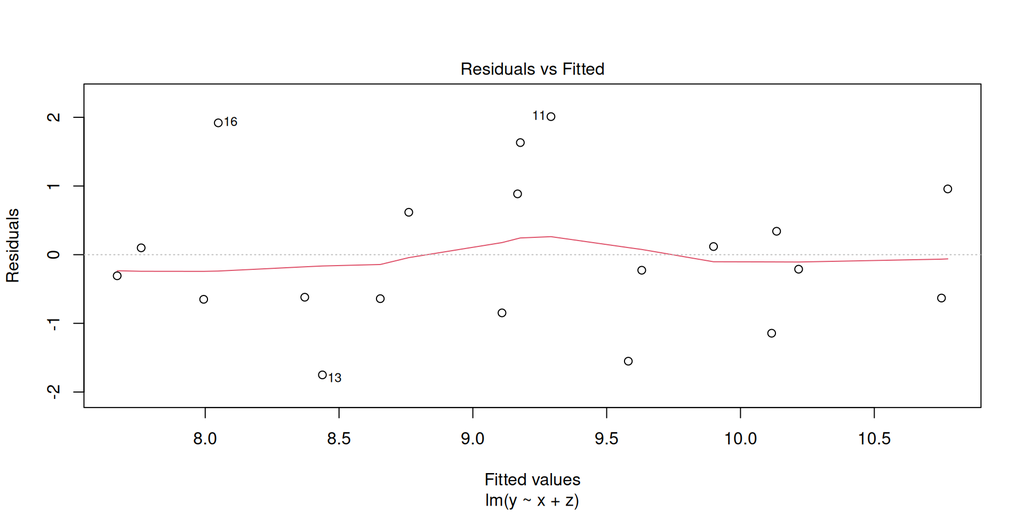

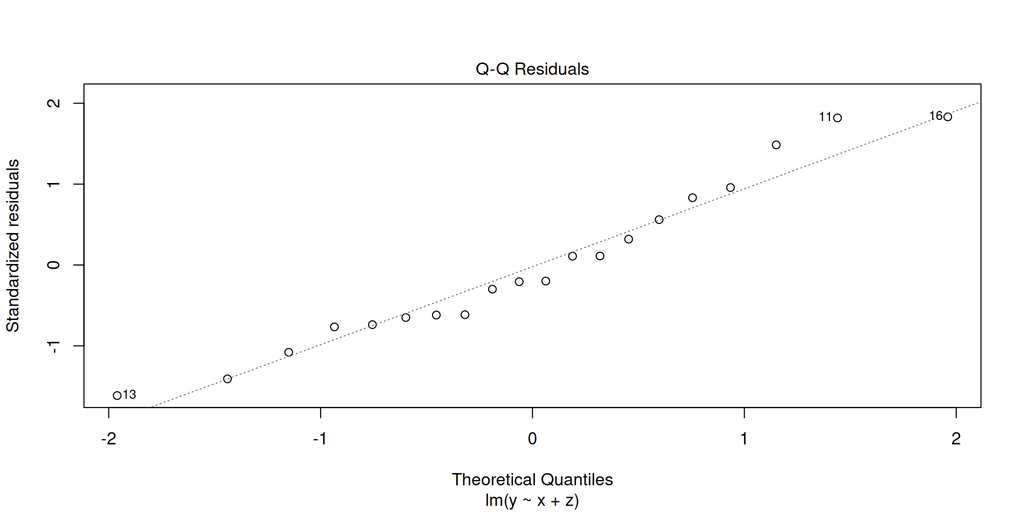

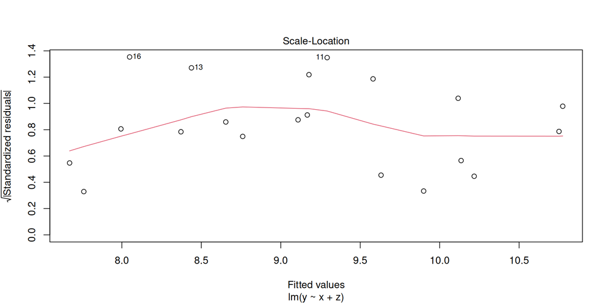

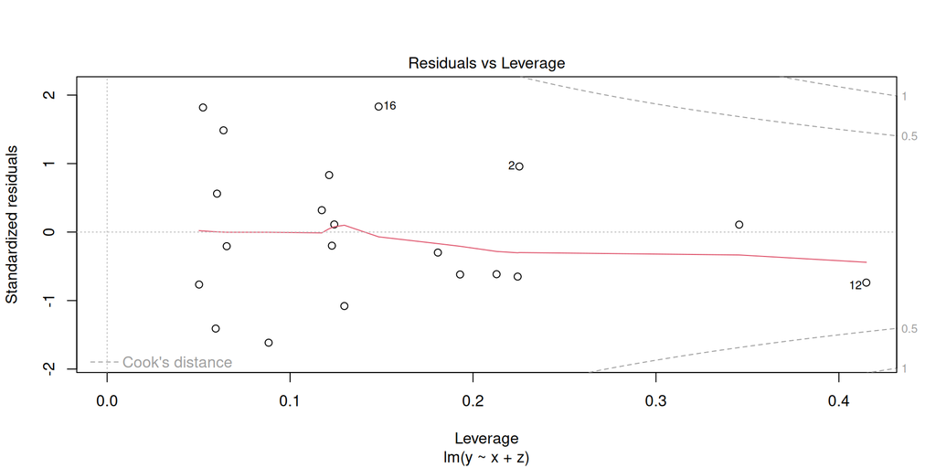

```r
plot(reg)
```

which gives us two more plots: one called “scale-location” and another called “leverage”. The scale-location plot can also aid in checking the homoscedasticity assumption.

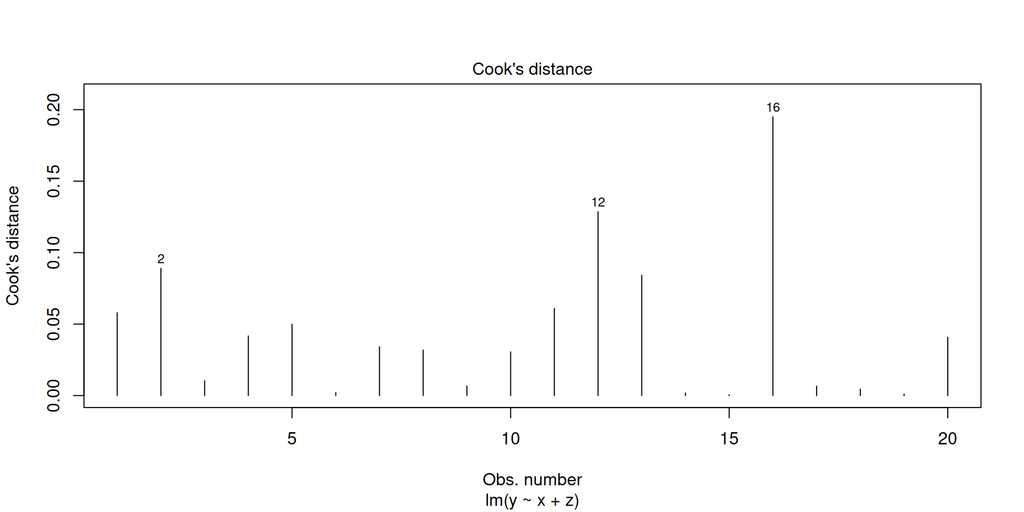

```r
plot(reg, which = 4)
```

Besides the plots base R can provide us with, there are many R-packages that create their own diagnostic plots. The `car` and `arm` packages are among these, and have various functions for plotting residuals, such as `car::residualPlots` or `car::qqPlot` and `arm::residual.plot`. Whether or not you prefer base R plots or a set of plots from another R-package is largely personal preference. The ones from the `car` package might look a little nicer, and it performs some basic tests to check if there is curvature in the residuals that is unaccounted for:

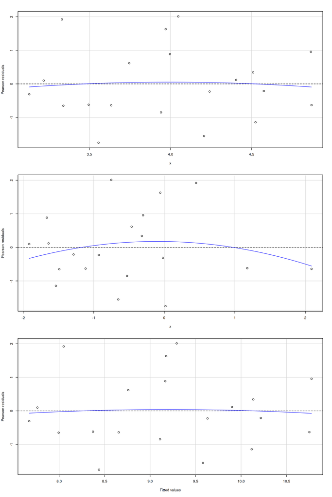

```
##            Test stat Pr(>|Test stat|)
## x            -0.1893           0.8522
## z            -0.7807           0.4464
## Tukey test   -0.1496           0.8811
```

```r
car::residualPlots(reg, layout = c(3, 1))
```

Finally, we can also plot our model against our data, to see if it is a good fit:

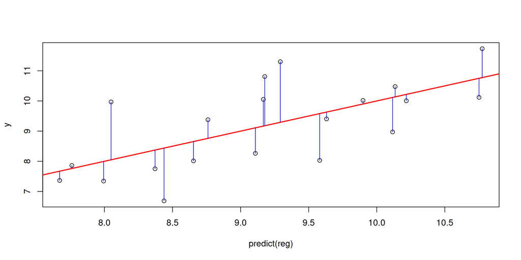

```r
plot(y ~ predict(reg), xlim = range(predict(reg)), ylim = range(y))
abline(0, 1, col = "red", lwd = 2)
segments(x0 = predict(reg), x1 = predict(reg), y0 = predict(reg), y1 = y, col = "blue")
```

any systematic deviations should be examined.

A few of the functions you may need for this practical:

- `plot`: draws all kinds of plots (controlled by `type`), but usually a scatterplot
- `abline`: draws a straight line through a plot. Accepts a model as input (only for simple linear regression)
- `lm`: fits a linear regression to data
- `summary`: provides a summary table for a (linear) model
- `confint`: calculates (estimated) confidence intervals for the parameters of a model
- `predict`: calculates the predicted values from a regression, potentially for new $X$
- `pairs`: construct a panel of plots for a dataset
- `residuals`: retrieves the residuals of a model (see also `rstandard` and `rstudent`)
- `cooks.distance`: calculates cook’s distance for each observation in the model
- `qqnorm` and `qqline`: function to construct your own QQ-plot
- `fitted`: returns the predicted/fitted values from your regression
- `glmtoolbox::leverage`: calculate leverage for a regression
- `hatvalues`: returns the influence for each observation in the regression

# Datasets

We will use the same datasets as in the last practical. You can find the datasets in the “data” folder of the github repository.

1. [nickel.expand](https://raw.githubusercontent.com/BertvanderVeen/GLM-workshop/refs/heads/main/data/nickel.expand.csv): Lung cancer due to nickel exposure in South Wales [Breslow and Day (1987)](https://pubmed.ncbi.nlm.nih.gov/3329634/)
2. [dmn](https://raw.githubusercontent.com/BertvanderVeen/GLM-workshop/refs/heads/main/data/dmn.csv): de novo mutations in children [Halldorsson et al. (2019)](https://www.science.org/doi/10.1126/science.aau1043), see also [this page](https://mccoy-lab.github.io/hgv_modules/setup.html)
3. [ISIT](https://raw.githubusercontent.com/BertvanderVeen/GLM-workshop/refs/heads/main/data/ISIT.csv): Pelagic bioluminescence (“Sources”) along a depth gradient in different seasons ([Gillibrand et al. 2007](https://www.int-res.com/abstracts/meps/v341/p37-44/))
4. [TeethNitrogen](https://raw.githubusercontent.com/BertvanderVeen/GLM-workshop/refs/heads/main/data/TeethNitrogen.csv): Nitrogen isotope ratios in teeth of stranded whales ([Mendes et al. 2007](https://link.springer.com/article/10.1007/s00442-006-0612-z))

The datasets are all stored in as “.csv” files, which means that you can load them into R by using the `read.csv("...")` function. You need to replace “…” by the link of the dataset, which you can copy by right-clicking the dataset name and choosing “copy link address”.

# Part 1: Anscombe’s quartet

The `anscombe` dataset is built into R and can be loaded with `data(anscombe)`. It contains four pairs of x and y variables (`x1`/`y1` through `x4`/`y4`) that all produce nearly identical regression summaries, but look very different.

1. Fit a simple linear regression for each of the four datasets: `lm(y1~x1)`, `lm(y2~x2)`, etc. Compare the coefficients and $R^2$ across models.
2. Use `plot` to visualize the residuals of each model.
3. Which assumptions are violated in each case, and how can you tell?

# Part 2

Here is what I want you to do:

1. Fit a multiple linear regression, you can continue where you left off during the last practical.
2. Use `plot` to visualize the residuals of the model.
3. Determine which assumptions are violated:
- linearity
- normality
- independence of errors
- homoscedasticity
4. Which plot(s) did you use to conclude an assumption was violated in 3.?

# Part 3

**Open after Part 2**

Assumption violations can generally be addressed by adjusting to model to accommodate the issue. Some of the assumption violations are more difficult to accommodate than others. Violation of:

- linearity: can be addressed by specifying functions of covariates; quadratic or more non-linear terms
- normality: can be pragmatically addressed by normalizing the data (`log(y)` for example) before regression
- independence of errors: this one is tricky, we might come back to it on friday, but occasionally it can be accounted for by including a missing covariate
- homoscedasticity: can be pragmatically addressed by applying a variance-stabilizing transformation (`sqrt(y)`for example) before regression, or by incorporating a missing covariate

Especially normality and homoscedasticity are issues that arise when fitting a linear model when you should be fitting a generalised linear model to your data instead.

Here is what I want you to do:

1. Try to improve your model. The basis for this is an assumption violation.
- if you did not find any, pick another dataset and try again.
2. How did you address the assumption violation?
3. Compare the model estimates, and standard errors or confidence intervals, with those of the uncorrected model. Did anything change?

[If you finish early you can pick a different dataset, or there is also the 2024 edition of this practical.](https://htmlpreview.github.io/?https://github.com/BertvanderVeen/GLM-workshop/blob/main/Practicals/2024/4Practical.html)

You can also try simulating data from a (multiple) linear regression where the assumptions are violated!